# Risk Factor Analysis

## Outcome Variable

**Outcome Variable:** sstunted

## Predictor Variables

**Intervention Variable:** gagebrth

**Adjustment Set:**

unadjusted

## Stratifying Variables

The analysis was stratified on these variable(s):

- agecat
- studyid

The following strata were considered:

- agecat: 12 months, studyid: ki1000108-CMC-V-BCS-2002
- agecat: 12 months, studyid: ki1000108-IRC
- agecat: 12 months, studyid: ki1000109-EE
- agecat: 12 months, studyid: ki1066203-TanzaniaChild2
- agecat: 12 months, studyid: ki1101329-Keneba
- agecat: 12 months, studyid: ki1113344-GMS-Nepal
- agecat: 12 months, studyid: ki1135781-COHORTS
- agecat: 18 months, studyid: ki1000108-CMC-V-BCS-2002
- agecat: 18 months, studyid: ki1000108-IRC
- agecat: 18 months, studyid: ki1000109-EE
- agecat: 18 months, studyid: ki1066203-TanzaniaChild2
- agecat: 18 months, studyid: ki1101329-Keneba
- agecat: 18 months, studyid: ki1113344-GMS-Nepal
- agecat: 18 months, studyid: ki1135781-COHORTS
- agecat: 24 months, studyid: ki1000108-CMC-V-BCS-2002
- agecat: 24 months, studyid: ki1000108-IRC
- agecat: 24 months, studyid: ki1066203-TanzaniaChild2
- agecat: 24 months, studyid: ki1101329-Keneba
- agecat: 24 months, studyid: ki1113344-GMS-Nepal
- agecat: 24 months, studyid: ki1135781-COHORTS
- agecat: 3 months, studyid: ki1000108-CMC-V-BCS-2002
- agecat: 3 months, studyid: ki1000108-IRC
- agecat: 3 months, studyid: ki1000109-EE
- agecat: 3 months, studyid: ki1066203-TanzaniaChild2
- agecat: 3 months, studyid: ki1101329-Keneba
- agecat: 3 months, studyid: ki1113344-GMS-Nepal
- agecat: 3 months, studyid: ki1135781-COHORTS
- agecat: 6 months, studyid: ki1000108-CMC-V-BCS-2002
- agecat: 6 months, studyid: ki1000108-IRC
- agecat: 6 months, studyid: ki1000109-EE
- agecat: 6 months, studyid: ki1066203-TanzaniaChild2
- agecat: 6 months, studyid: ki1101329-Keneba
- agecat: 6 months, studyid: ki1113344-GMS-Nepal
- agecat: 6 months, studyid: ki1135781-COHORTS
- agecat: 9 months, studyid: ki1000108-CMC-V-BCS-2002
- agecat: 9 months, studyid: ki1000108-IRC
- agecat: 9 months, studyid: ki1000109-EE
- agecat: 9 months, studyid: ki1066203-TanzaniaChild2
- agecat: 9 months, studyid: ki1101329-Keneba
- agecat: 9 months, studyid: ki1113344-GMS-Nepal
- agecat: 9 months, studyid: ki1135781-COHORTS
- agecat: Birth, studyid: ki1000108-CMC-V-BCS-2002
- agecat: Birth, studyid: ki1000108-IRC
- agecat: Birth, studyid: ki1000109-EE
- agecat: Birth, studyid: ki1101329-Keneba
- agecat: Birth, studyid: ki1135781-COHORTS

### Dropped Strata

Some strata were dropped due to rare outcomes:

- agecat: Birth, studyid: ki1000108-CMC-V-BCS-2002
- agecat: Birth, studyid: ki1000108-IRC
- agecat: Birth, studyid: ki1000109-EE
- agecat: Birth, studyid: ki1101329-Keneba
- agecat: 3 months, studyid: ki1000108-IRC
- agecat: 3 months, studyid: ki1000109-EE
- agecat: 3 months, studyid: ki1066203-TanzaniaChild2
- agecat: 3 months, studyid: ki1101329-Keneba
- agecat: 3 months, studyid: ki1113344-GMS-Nepal
- agecat: 6 months, studyid: ki1000108-IRC
- agecat: 6 months, studyid: ki1000109-EE
- agecat: 6 months, studyid: ki1066203-TanzaniaChild2
- agecat: 6 months, studyid: ki1101329-Keneba
- agecat: 6 months, studyid: ki1113344-GMS-Nepal
- agecat: 9 months, studyid: ki1000108-IRC
- agecat: 9 months, studyid: ki1000109-EE
- agecat: 9 months, studyid: ki1066203-TanzaniaChild2
- agecat: 9 months, studyid: ki1113344-GMS-Nepal
- agecat: 12 months, studyid: ki1000109-EE
- agecat: 12 months, studyid: ki1066203-TanzaniaChild2
- agecat: 12 months, studyid: ki1113344-GMS-Nepal
- agecat: 18 months, studyid: ki1000108-IRC
- agecat: 18 months, studyid: ki1000109-EE
- agecat: 18 months, studyid: ki1066203-TanzaniaChild2
- agecat: 18 months, studyid: ki1113344-GMS-Nepal
- agecat: 24 months, studyid: ki1000108-IRC
- agecat: 24 months, studyid: ki1066203-TanzaniaChild2
- agecat: 24 months, studyid: ki1113344-GMS-Nepal

## Methods Detail

We’re interested in the causal parameters $E[Y_a]$ for all values of $a \in \mathcal{A}$. These parameters represent the mean outcome if, possibly contrary to fact, we intervened to set all units to have $A=a$. Under the randomization and positivity assumptions, these are identified by the statistical parameters $\psi_a=E_W[E_{Y|A,W}(Y|A=a,W)]$. In addition, we’re interested in the mean of $Y$, $E[Y]$ under no intervention (the observed mean). We will estimate these parameters by using SuperLearner to fit the relevant likelihood factors – $E_{Y|A,W}(Y|A=a,W)$ and $p(A=a|W)$, and then updating our likelihood fit using a joint TMLE.

For unadjusted analyses ($W=\{\}$), initial likelihoods were estimated using Lrnr_glm to estimate the simple $E(Y|A)$ and Lrnr_mean to estimate $p(A)$. For adjusted analyses, a small library containing Lrnr_glmnet, Lrnr_xgboost, and Lrnr_mean was used.

Having estimated these parameters, we will then use the delta method to estimate relative risks and attributable risks relative to a prespecified baseline level of $A$.

# Results Detail

## Results Plots

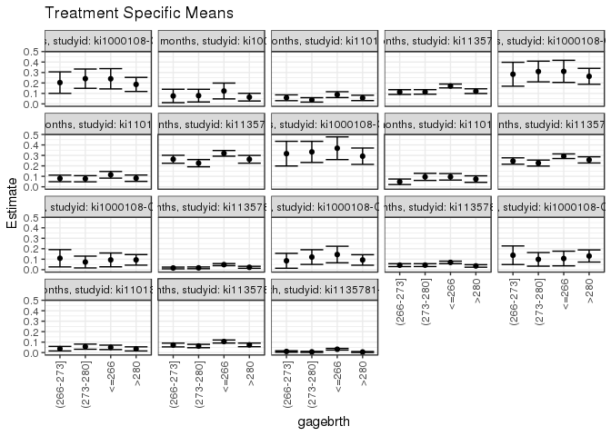

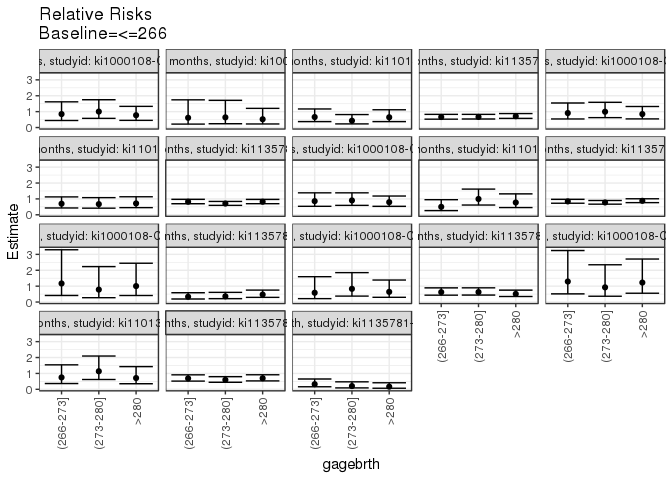

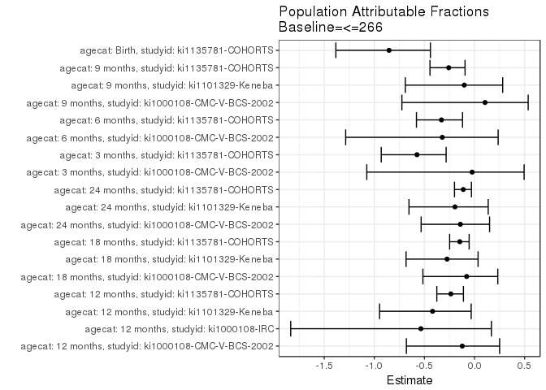

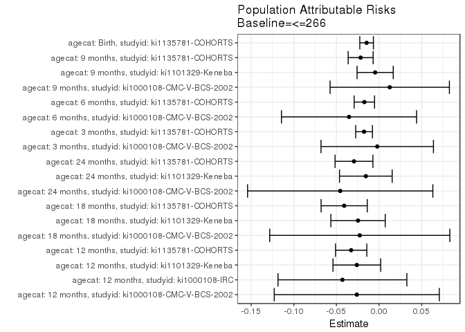

## Data Summary

| agecat | studyid | A | n | nA | nAY0 | nAY1 |
| --- | --- | --- | --- | --- | --- | --- |
| Birth | ki1000108-CMC-V-BCS-2002 | <=266 | 90 | 18 | 18 | 0 |
| Birth | ki1000108-CMC-V-BCS-2002 | (266-273] | 90 | 15 | 15 | 0 |
| Birth | ki1000108-CMC-V-BCS-2002 | (273-280] | 90 | 18 | 16 | 2 |
| Birth | ki1000108-CMC-V-BCS-2002 | >280 | 90 | 39 | 38 | 1 |
| Birth | ki1000108-IRC | <=266 | 369 | 66 | 63 | 3 |
| Birth | ki1000108-IRC | (266-273] | 369 | 65 | 63 | 2 |
| Birth | ki1000108-IRC | (273-280] | 369 | 71 | 69 | 2 |
| Birth | ki1000108-IRC | >280 | 369 | 167 | 159 | 8 |
| Birth | ki1000109-EE | <=266 | 2 | 2 | 2 | 0 |
| Birth | ki1000109-EE | (266-273] | 2 | 0 | 0 | 0 |
| Birth | ki1000109-EE | (273-280] | 2 | 0 | 0 | 0 |
| Birth | ki1000109-EE | >280 | 2 | 0 | 0 | 0 |
| Birth | ki1066203-TanzaniaChild2 | <=266 | 0 | 0 | 0 | 0 |
| Birth | ki1066203-TanzaniaChild2 | (266-273] | 0 | 0 | 0 | 0 |
| Birth | ki1066203-TanzaniaChild2 | (273-280] | 0 | 0 | 0 | 0 |
| Birth | ki1066203-TanzaniaChild2 | >280 | 0 | 0 | 0 | 0 |
| Birth | ki1101329-Keneba | <=266 | 1515 | 457 | 440 | 17 |
| Birth | ki1101329-Keneba | (266-273] | 1515 | 324 | 320 | 4 |
| Birth | ki1101329-Keneba | (273-280] | 1515 | 360 | 356 | 4 |
| Birth | ki1101329-Keneba | >280 | 1515 | 374 | 370 | 4 |
| Birth | ki1113344-GMS-Nepal | <=266 | 0 | 0 | 0 | 0 |
| Birth | ki1113344-GMS-Nepal | (266-273] | 0 | 0 | 0 | 0 |
| Birth | ki1113344-GMS-Nepal | (273-280] | 0 | 0 | 0 | 0 |
| Birth | ki1113344-GMS-Nepal | >280 | 0 | 0 | 0 | 0 |
| Birth | ki1135781-COHORTS | <=266 | 4607 | 1857 | 1798 | 59 |
| Birth | ki1135781-COHORTS | (266-273] | 4607 | 876 | 867 | 9 |
| Birth | ki1135781-COHORTS | (273-280] | 4607 | 926 | 920 | 6 |
| Birth | ki1135781-COHORTS | >280 | 4607 | 948 | 943 | 5 |
| 3 months | ki1000108-CMC-V-BCS-2002 | <=266 | 340 | 75 | 68 | 7 |
| 3 months | ki1000108-CMC-V-BCS-2002 | (266-273] | 340 | 55 | 49 | 6 |

[output cut: 166 more lines]

## Results Table

### Parameter: TSM

| agecat | studyid | intervention_level | baseline_level | estimate | ci_lower | ci_upper |
| --- | --- | --- | --- | --- | --- | --- |
| Birth | ki1135781-COHORTS | <=266 | NA | 0.0317717 | 0.0237936 | 0.0397498 |
| Birth | ki1135781-COHORTS | (266-273] | NA | 0.0102740 | 0.0035956 | 0.0169523 |
| Birth | ki1135781-COHORTS | (273-280] | NA | 0.0064795 | 0.0013112 | 0.0116478 |
| Birth | ki1135781-COHORTS | >280 | NA | 0.0052743 | 0.0006630 | 0.0098856 |
| 3 months | ki1000108-CMC-V-BCS-2002 | <=266 | NA | 0.0933333 | 0.0274009 | 0.1592658 |
| 3 months | ki1000108-CMC-V-BCS-2002 | (266-273] | NA | 0.1090909 | 0.0265789 | 0.1916030 |
| 3 months | ki1000108-CMC-V-BCS-2002 | (273-280] | NA | 0.0731707 | 0.0167226 | 0.1296188 |
| 3 months | ki1000108-CMC-V-BCS-2002 | >280 | NA | 0.0937500 | 0.0431801 | 0.1443199 |
| 3 months | ki1135781-COHORTS | <=266 | NA | 0.0482456 | 0.0384106 | 0.0580806 |
| 3 months | ki1135781-COHORTS | (266-273] | NA | 0.0161850 | 0.0077749 | 0.0245951 |
| 3 months | ki1135781-COHORTS | (273-280] | NA | 0.0173724 | 0.0089334 | 0.0258114 |
| 3 months | ki1135781-COHORTS | >280 | NA | 0.0227027 | 0.0131026 | 0.0323028 |
| 6 months | ki1000108-CMC-V-BCS-2002 | <=266 | NA | 0.1447368 | 0.0655218 | 0.2239518 |
| 6 months | ki1000108-CMC-V-BCS-2002 | (266-273] | NA | 0.0847458 | 0.0135788 | 0.1559128 |
| 6 months | ki1000108-CMC-V-BCS-2002 | (273-280] | NA | 0.1204819 | 0.0503495 | 0.1906144 |
| 6 months | ki1000108-CMC-V-BCS-2002 | >280 | NA | 0.0930233 | 0.0428267 | 0.1432198 |
| 6 months | ki1135781-COHORTS | <=266 | NA | 0.0694604 | 0.0575202 | 0.0814005 |
| 6 months | ki1135781-COHORTS | (266-273] | NA | 0.0431655 | 0.0293711 | 0.0569598 |
| 6 months | ki1135781-COHORTS | (273-280] | NA | 0.0436280 | 0.0300610 | 0.0571951 |
| 6 months | ki1135781-COHORTS | >280 | NA | 0.0355951 | 0.0234823 | 0.0477079 |
| 9 months | ki1000108-CMC-V-BCS-2002 | <=266 | NA | 0.1066667 | 0.0367033 | 0.1766300 |
| 9 months | ki1000108-CMC-V-BCS-2002 | (266-273] | NA | 0.1379310 | 0.0490584 | 0.2268037 |
| 9 months | ki1000108-CMC-V-BCS-2002 | (273-280] | NA | 0.0987654 | 0.0336987 | 0.1638322 |
| 9 months | ki1000108-CMC-V-BCS-2002 | >280 | NA | 0.1307692 | 0.0727290 | 0.1888094 |
| 9 months | ki1101329-Keneba | <=266 | NA | 0.0496278 | 0.0284167 | 0.0708389 |
| 9 months | ki1101329-Keneba | (266-273] | NA | 0.0371622 | 0.0156052 | 0.0587191 |
| 9 months | ki1101329-Keneba | (273-280] | NA | 0.0563798 | 0.0317449 | 0.0810148 |
| 9 months | ki1101329-Keneba | >280 | NA | 0.0351906 | 0.0156264 | 0.0547548 |
| 9 months | ki1135781-COHORTS | <=266 | NA | 0.1055425 | 0.0909180 | 0.1201669 |
| 9 months | ki1135781-COHORTS | (266-273] | NA | 0.0723192 | 0.0543909 | 0.0902475 |
| 9 months | ki1135781-COHORTS | (273-280] | NA | 0.0627178 | 0.0465210 | 0.0789145 |
| 9 months | ki1135781-COHORTS | >280 | NA | 0.0734266 | 0.0559715 | 0.0908817 |
| 12 months | ki1000108-CMC-V-BCS-2002 | <=266 | NA | 0.2400000 | 0.1432038 | 0.3367962 |
| 12 months | ki1000108-CMC-V-BCS-2002 | (266-273] | NA | 0.2033898 | 0.1005318 | 0.3062478 |
| 12 months | ki1000108-CMC-V-BCS-2002 | (273-280] | NA | 0.2409639 | 0.1488246 | 0.3331031 |
| 12 months | ki1000108-CMC-V-BCS-2002 | >280 | NA | 0.1860465 | 0.1187965 | 0.2532965 |
| 12 months | ki1000108-IRC | <=266 | NA | 0.1232877 | 0.0477718 | 0.1988036 |
| 12 months | ki1000108-IRC | (266-273] | NA | 0.0757576 | 0.0118363 | 0.1396788 |
| 12 months | ki1000108-IRC | (273-280] | NA | 0.0789474 | 0.0182436 | 0.1396511 |
| 12 months | ki1000108-IRC | >280 | NA | 0.0643275 | 0.0275084 | 0.1011466 |
| 12 months | ki1101329-Keneba | <=266 | NA | 0.0883838 | 0.0604159 | 0.1163517 |
| 12 months | ki1101329-Keneba | (266-273] | NA | 0.0583942 | 0.0306188 | 0.0861695 |
| 12 months | ki1101329-Keneba | (273-280] | NA | 0.0380952 | 0.0169476 | 0.0592428 |
| 12 months | ki1101329-Keneba | >280 | NA | 0.0571429 | 0.0315002 | 0.0827856 |
| 12 months | ki1135781-COHORTS | <=266 | NA | 0.1711823 | 0.1528605 | 0.1895041 |
| 12 months | ki1135781-COHORTS | (266-273] | NA | 0.1131579 | 0.0906331 | 0.1356827 |
| 12 months | ki1135781-COHORTS | (273-280] | NA | 0.1143201 | 0.0926829 | 0.1359573 |
| 12 months | ki1135781-COHORTS | >280 | NA | 0.1216545 | 0.0993053 | 0.1440037 |
| 18 months | ki1000108-CMC-V-BCS-2002 | <=266 | NA | 0.3108108 | 0.2052078 | 0.4164138 |
| 18 months | ki1000108-CMC-V-BCS-2002 | (266-273] | NA | 0.2833333 | 0.1691490 | 0.3975177 |
| 18 months | ki1000108-CMC-V-BCS-2002 | (273-280] | NA | 0.3095238 | 0.2105189 | 0.4085287 |
| 18 months | ki1000108-CMC-V-BCS-2002 | >280 | NA | 0.2635659 | 0.1874296 | 0.3397021 |
| 18 months | ki1101329-Keneba | <=266 | NA | 0.1145833 | 0.0827132 | 0.1464535 |
| 18 months | ki1101329-Keneba | (266-273] | NA | 0.0798611 | 0.0485417 | 0.1111805 |
| 18 months | ki1101329-Keneba | (273-280] | NA | 0.0769231 | 0.0473440 | 0.1065022 |
| 18 months | ki1101329-Keneba | >280 | NA | 0.0820189 | 0.0518014 | 0.1122365 |
| 18 months | ki1135781-COHORTS | <=266 | NA | 0.3196147 | 0.2925637 | 0.3466658 |
| 18 months | ki1135781-COHORTS | (266-273] | NA | 0.2630561 | 0.2250964 | 0.3010158 |
| 18 months | ki1135781-COHORTS | (273-280] | NA | 0.2257496 | 0.1913313 | 0.2601678 |
| 18 months | ki1135781-COHORTS | >280 | NA | 0.2628676 | 0.2258705 | 0.2998648 |
| 24 months | ki1000108-CMC-V-BCS-2002 | <=266 | NA | 0.3684211 | 0.2598163 | 0.4770258 |
| 24 months | ki1000108-CMC-V-BCS-2002 | (266-273] | NA | 0.3166667 | 0.1987945 | 0.4345388 |
| 24 months | ki1000108-CMC-V-BCS-2002 | (273-280] | NA | 0.3333333 | 0.2323793 | 0.4342873 |
| 24 months | ki1000108-CMC-V-BCS-2002 | >280 | NA | 0.2923077 | 0.2140116 | 0.3706038 |
| 24 months | ki1101329-Keneba | <=266 | NA | 0.0951009 | 0.0642218 | 0.1259799 |
| 24 months | ki1101329-Keneba | (266-273] | NA | 0.0476190 | 0.0213145 | 0.0739236 |
| 24 months | ki1101329-Keneba | (273-280] | NA | 0.0947368 | 0.0607226 | 0.1287511 |
| 24 months | ki1101329-Keneba | >280 | NA | 0.0735294 | 0.0424983 | 0.1045606 |
| 24 months | ki1135781-COHORTS | <=266 | NA | 0.2922601 | 0.2700762 | 0.3144439 |
| 24 months | ki1135781-COHORTS | (266-273] | NA | 0.2461140 | 0.2157252 | 0.2765028 |
| 24 months | ki1135781-COHORTS | (273-280] | NA | 0.2266667 | 0.1980939 | 0.2552394 |
| 24 months | ki1135781-COHORTS | >280 | NA | 0.2571429 | 0.2275830 | 0.2867027 |

### Parameter: E(Y)

| agecat | studyid | intervention_level | baseline_level | estimate | ci_lower | ci_upper |
| --- | --- | --- | --- | --- | --- | --- |
| Birth | ki1135781-COHORTS | NA | NA | 0.0171478 | 0.0167976 | 0.0174980 |
| 3 months | ki1000108-CMC-V-BCS-2002 | NA | NA | 0.0911765 | 0.0899459 | 0.0924070 |
| 3 months | ki1135781-COHORTS | NA | NA | 0.0306505 | 0.0302256 | 0.0310754 |
| 6 months | ki1000108-CMC-V-BCS-2002 | NA | NA | 0.1095101 | 0.1071401 | 0.1118801 |
| 6 months | ki1135781-COHORTS | NA | NA | 0.0522319 | 0.0518043 | 0.0526596 |
| 9 months | ki1000108-CMC-V-BCS-2002 | NA | NA | 0.1191860 | 0.1175387 | 0.1208334 |
| 9 months | ki1101329-Keneba | NA | NA | 0.0450254 | 0.0445679 | 0.0454830 |
| 9 months | ki1135781-COHORTS | NA | NA | 0.0839459 | 0.0833994 | 0.0844925 |
| 12 months | ki1000108-CMC-V-BCS-2002 | NA | NA | 0.2138728 | 0.2112212 | 0.2165244 |
| 12 months | ki1000108-IRC | NA | NA | 0.0803109 | 0.0781537 | 0.0824681 |
| 12 months | ki1101329-Keneba | NA | NA | 0.0623077 | 0.0612775 | 0.0633379 |
| 12 months | ki1135781-COHORTS | NA | NA | 0.1384692 | 0.1376363 | 0.1393020 |
| 18 months | ki1000108-CMC-V-BCS-2002 | NA | NA | 0.2881844 | 0.2859522 | 0.2904166 |
| 18 months | ki1101329-Keneba | NA | NA | 0.0899308 | 0.0890583 | 0.0908034 |
| 18 months | ki1135781-COHORTS | NA | NA | 0.2787004 | 0.2773273 | 0.2800734 |
| 24 months | ki1000108-CMC-V-BCS-2002 | NA | NA | 0.3228571 | 0.3198339 | 0.3258803 |
| 24 months | ki1101329-Keneba | NA | NA | 0.0795848 | 0.0784902 | 0.0806794 |
| 24 months | ki1135781-COHORTS | NA | NA | 0.2628332 | 0.2620352 | 0.2636311 |

### Parameter: RR

| agecat | studyid | intervention_level | baseline_level | estimate | ci_lower | ci_upper |
| --- | --- | --- | --- | --- | --- | --- |
| Birth | ki1135781-COHORTS | (266-273] | <=266 | 0.3233689 | 0.1610881 | 0.6491323 |
| Birth | ki1135781-COHORTS | (273-280] | <=266 | 0.2039389 | 0.0883748 | 0.4706217 |
| Birth | ki1135781-COHORTS | >280 | <=266 | 0.1660051 | 0.0668446 | 0.4122653 |
| 3 months | ki1000108-CMC-V-BCS-2002 | (266-273] | <=266 | 1.1688312 | 0.4152229 | 3.2901997 |
| 3 months | ki1000108-CMC-V-BCS-2002 | (273-280] | <=266 | 0.7839721 | 0.2754333 | 2.2314380 |
| 3 months | ki1000108-CMC-V-BCS-2002 | >280 | <=266 | 1.0044643 | 0.4129777 | 2.4431067 |
| 3 months | ki1135781-COHORTS | (266-273] | <=266 | 0.3354704 | 0.1919729 | 0.5862306 |
| 3 months | ki1135781-COHORTS | (273-280] | <=266 | 0.3600829 | 0.2126239 | 0.6098078 |
| 3 months | ki1135781-COHORTS | >280 | <=266 | 0.4705651 | 0.2942705 | 0.7524761 |
| 6 months | ki1000108-CMC-V-BCS-2002 | (266-273] | <=266 | 0.5855162 | 0.2148884 | 1.5953827 |
| 6 months | ki1000108-CMC-V-BCS-2002 | (273-280] | <=266 | 0.8324206 | 0.3744096 | 1.8507112 |
| 6 months | ki1000108-CMC-V-BCS-2002 | >280 | <=266 | 0.6427061 | 0.2980027 | 1.3861325 |
| 6 months | ki1135781-COHORTS | (266-273] | <=266 | 0.6214400 | 0.4323219 | 0.8932873 |
| 6 months | ki1135781-COHORTS | (273-280] | <=266 | 0.6280992 | 0.4402657 | 0.8960693 |
| 6 months | ki1135781-COHORTS | >280 | <=266 | 0.5124519 | 0.3500097 | 0.7502846 |
| 9 months | ki1000108-CMC-V-BCS-2002 | (266-273] | <=266 | 1.2931034 | 0.5156148 | 3.2429568 |
| 9 months | ki1000108-CMC-V-BCS-2002 | (273-280] | <=266 | 0.9259259 | 0.3654587 | 2.3459251 |
| 9 months | ki1000108-CMC-V-BCS-2002 | >280 | <=266 | 1.2259615 | 0.5553054 | 2.7065858 |
| 9 months | ki1101329-Keneba | (266-273] | <=266 | 0.7488176 | 0.3642955 | 1.5392112 |
| 9 months | ki1101329-Keneba | (273-280] | <=266 | 1.1360534 | 0.6165203 | 2.0933898 |
| 9 months | ki1101329-Keneba | >280 | <=266 | 0.7090909 | 0.3516836 | 1.4297225 |
| 9 months | ki1135781-COHORTS | (266-273] | <=266 | 0.6852143 | 0.5158056 | 0.9102629 |
| 9 months | ki1135781-COHORTS | (273-280] | <=266 | 0.5942421 | 0.4432849 | 0.7966067 |
| 9 months | ki1135781-COHORTS | >280 | <=266 | 0.6957065 | 0.5283558 | 0.9160637 |
| 12 months | ki1000108-CMC-V-BCS-2002 | (266-273] | <=266 | 0.8474576 | 0.4438070 | 1.6182360 |
| 12 months | ki1000108-CMC-V-BCS-2002 | (273-280] | <=266 | 1.0040161 | 0.5759353 | 1.7502802 |
| 12 months | ki1000108-CMC-V-BCS-2002 | >280 | <=266 | 0.7751938 | 0.4510231 | 1.3323608 |
| 12 months | ki1000108-IRC | (266-273] | <=266 | 0.6144781 | 0.2166163 | 1.7430977 |
| 12 months | ki1000108-IRC | (273-280] | <=266 | 0.6403509 | 0.2395965 | 1.7114161 |
| 12 months | ki1000108-IRC | >280 | <=266 | 0.5217674 | 0.2256305 | 1.2065797 |
| 12 months | ki1101329-Keneba | (266-273] | <=266 | 0.6606882 | 0.3731526 | 1.1697867 |
| 12 months | ki1101329-Keneba | (273-280] | <=266 | 0.4310204 | 0.2275057 | 0.8165889 |
| 12 months | ki1101329-Keneba | >280 | <=266 | 0.6465306 | 0.3733530 | 1.1195887 |
| 12 months | ki1135781-COHORTS | (266-273] | <=266 | 0.6610375 | 0.5273181 | 0.8286660 |
| 12 months | ki1135781-COHORTS | (273-280] | <=266 | 0.6678267 | 0.5373197 | 0.8300320 |
| 12 months | ki1135781-COHORTS | >280 | <=266 | 0.7106723 | 0.5745552 | 0.8790368 |
| 18 months | ki1000108-CMC-V-BCS-2002 | (266-273] | <=266 | 0.9115942 | 0.5381177 | 1.5442791 |
| 18 months | ki1000108-CMC-V-BCS-2002 | (273-280] | <=266 | 0.9958592 | 0.6245093 | 1.5880238 |
| 18 months | ki1000108-CMC-V-BCS-2002 | >280 | <=266 | 0.8479946 | 0.5428901 | 1.3245679 |
| 18 months | ki1101329-Keneba | (266-273] | <=266 | 0.6969697 | 0.4309317 | 1.1272477 |
| 18 months | ki1101329-Keneba | (273-280] | <=266 | 0.6713287 | 0.4176658 | 1.0790498 |
| 18 months | ki1101329-Keneba | >280 | <=266 | 0.7158015 | 0.4511409 | 1.1357248 |
| 18 months | ki1135781-COHORTS | (266-273] | <=266 | 0.8230413 | 0.6962539 | 0.9729165 |
| 18 months | ki1135781-COHORTS | (273-280] | <=266 | 0.7063178 | 0.5932917 | 0.8408761 |
| 18 months | ki1135781-COHORTS | >280 | <=266 | 0.8224517 | 0.6978870 | 0.9692497 |
| 24 months | ki1000108-CMC-V-BCS-2002 | (266-273] | <=266 | 0.8595238 | 0.5346228 | 1.3818738 |
| 24 months | ki1000108-CMC-V-BCS-2002 | (273-280] | <=266 | 0.9047619 | 0.5929046 | 1.3806506 |
| 24 months | ki1000108-CMC-V-BCS-2002 | >280 | <=266 | 0.7934066 | 0.5327405 | 1.1816148 |
| 24 months | ki1101329-Keneba | (266-273] | <=266 | 0.5007215 | 0.2638267 | 0.9503284 |
| 24 months | ki1101329-Keneba | (273-280] | <=266 | 0.9961722 | 0.6139024 | 1.6164770 |
| 24 months | ki1101329-Keneba | >280 | <=266 | 0.7731729 | 0.4539672 | 1.3168272 |
| 24 months | ki1135781-COHORTS | (266-273] | <=266 | 0.8421061 | 0.7284846 | 0.9734492 |
| 24 months | ki1135781-COHORTS | (273-280] | <=266 | 0.7755650 | 0.6694435 | 0.8985091 |
| 24 months | ki1135781-COHORTS | >280 | <=266 | 0.8798426 | 0.7666184 | 1.0097892 |

### Parameter: PAR

| agecat | studyid | intervention_level | baseline_level | estimate | ci_lower | ci_upper |
| --- | --- | --- | --- | --- | --- | --- |
| Birth | ki1135781-COHORTS | <=266 | NA | -0.0146239 | -0.0226096 | -0.0066381 |
| 3 months | ki1000108-CMC-V-BCS-2002 | <=266 | NA | -0.0021569 | -0.0681008 | 0.0637871 |
| 3 months | ki1135781-COHORTS | <=266 | NA | -0.0175951 | -0.0274393 | -0.0077509 |
| 6 months | ki1000108-CMC-V-BCS-2002 | <=266 | NA | -0.0352268 | -0.1144772 | 0.0440237 |
| 6 months | ki1135781-COHORTS | <=266 | NA | -0.0172285 | -0.0291763 | -0.0052806 |
| 9 months | ki1000108-CMC-V-BCS-2002 | <=266 | NA | 0.0125194 | -0.0574634 | 0.0825021 |
| 9 months | ki1101329-Keneba | <=266 | NA | -0.0046024 | -0.0258184 | 0.0166136 |
| 9 months | ki1135781-COHORTS | <=266 | NA | -0.0215965 | -0.0362312 | -0.0069618 |
| 12 months | ki1000108-CMC-V-BCS-2002 | <=266 | NA | -0.0261272 | -0.1229597 | 0.0707054 |
| 12 months | ki1000108-IRC | <=266 | NA | -0.0429768 | -0.1185235 | 0.0325699 |
| 12 months | ki1101329-Keneba | <=266 | NA | -0.0260761 | -0.0540630 | 0.0019107 |
| 12 months | ki1135781-COHORTS | <=266 | NA | -0.0327131 | -0.0510538 | -0.0143724 |
| 18 months | ki1000108-CMC-V-BCS-2002 | <=266 | NA | -0.0226264 | -0.1282529 | 0.0830002 |
| 18 months | ki1101329-Keneba | <=266 | NA | -0.0246525 | -0.0565346 | 0.0072296 |
| 18 months | ki1135781-COHORTS | <=266 | NA | -0.0409144 | -0.0680002 | -0.0138285 |
| 24 months | ki1000108-CMC-V-BCS-2002 | <=266 | NA | -0.0455639 | -0.1542107 | 0.0630829 |
| 24 months | ki1101329-Keneba | <=266 | NA | -0.0155161 | -0.0464145 | 0.0153823 |
| 24 months | ki1135781-COHORTS | <=266 | NA | -0.0294269 | -0.0516251 | -0.0072287 |

### Parameter: PAF

| agecat | studyid | intervention_level | baseline_level | estimate | ci_lower | ci_upper |
| --- | --- | --- | --- | --- | --- | --- |
| Birth | ki1135781-COHORTS | <=266 | NA | -0.8528115 | -1.3836669 | -0.4401804 |
| 3 months | ki1000108-CMC-V-BCS-2002 | <=266 | NA | -0.0236559 | -1.0749324 | 0.4949853 |
| 3 months | ki1135781-COHORTS | <=266 | NA | -0.5740565 | -0.9308879 | -0.2831682 |
| 6 months | ki1000108-CMC-V-BCS-2002 | <=266 | NA | -0.3216759 | -1.2856076 | 0.2357274 |
| 6 months | ki1135781-COHORTS | <=266 | NA | -0.3298452 | -0.5795756 | -0.1195971 |
| 9 months | ki1000108-CMC-V-BCS-2002 | <=266 | NA | 0.1050407 | -0.7247382 | 0.5356094 |
| 9 months | ki1101329-Keneba | <=266 | NA | -0.1022172 | -0.6902015 | 0.2812201 |
| 9 months | ki1135781-COHORTS | <=266 | NA | -0.2572670 | -0.4443480 | -0.0944179 |
| 12 months | ki1000108-CMC-V-BCS-2002 | <=266 | NA | -0.1221622 | -0.6799523 | 0.2504264 |
| 12 months | ki1000108-IRC | <=266 | NA | -0.5351304 | -1.8340924 | 0.1684727 |
| 12 months | ki1101329-Keneba | <=266 | NA | -0.4185060 | -0.9473565 | -0.0332774 |
| 12 months | ki1135781-COHORTS | <=266 | NA | -0.2362483 | -0.3761379 | -0.1105790 |
| 18 months | ki1000108-CMC-V-BCS-2002 | <=266 | NA | -0.0785135 | -0.5150344 | 0.2322343 |
| 18 months | ki1101329-Keneba | <=266 | NA | -0.2741275 | -0.6829871 | 0.0354050 |
| 18 months | ki1135781-COHORTS | <=266 | NA | -0.1468041 | -0.2482702 | -0.0535857 |
| 24 months | ki1000108-CMC-V-BCS-2002 | <=266 | NA | -0.1411272 | -0.5325751 | 0.1503378 |
| 24 months | ki1101329-Keneba | <=266 | NA | -0.1949630 | -0.6538470 | 0.1365969 |
| 24 months | ki1135781-COHORTS | <=266 | NA | -0.1119603 | -0.1997218 | -0.0306187 |